# Experiments and Causal Inference

Erik Gahner Larsen

Advanced applied statistics, 2015

# Experiments in political science research

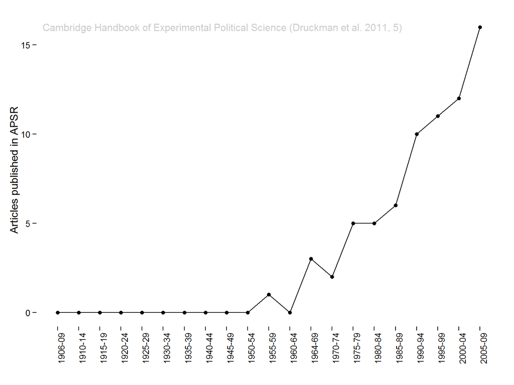

# “But I don’t care about experiments…”

- “Like it or not, social scientists rely on the logic of experimentation even when analyzing nonexperimental data.”[^1]
- “In some sense every empirical researcher is reporting the results of an experiment. Every researcher who behaves as if an exogenous variable varies independently of an error term effectively views their data as coming from an experiment.”[^2]
- “[T]here is no reason to suppose that case study research follows a divergent logic of inquiry relative to experimental research.”[^3]
- “If you can’t devise an experiment that answers your question in a world there anything goes, then the odds of generating useful results with a modest budget and nonexperimental survey data seem pretty slim. The description of an ideal experiment also helps you formulate causal questions precisely.”[^4]

# Agenda

- Background
  - Potential outcomes
  - Fundamental problem of causal inference
  - Counterfactuals
- Experiments (randomization, effect estimation)
- Types of experiments
  - Lab, survey, field, natural, quasi
- Practical guidelines

# Important: What’s it all about?

- From estimation strategies (*statistics*) to identification strategies (*design*):
  - “Without an experiment, a natural experiment, a discontinuity, or some other strong design, no amount of econometric or statistical modeling can make the move from correlation to causation persuasive.”[^5]
- The interesting thing is not the data we have
  - … but the data we do **not** have.
- “Easy” to measure the factual world
  - What about the *counter*factual world?
- Key point: We need theoretical and statistical tools to make valid counterfactuals

# Potential outcomes

# The Fundamental Problem of Causal Inference (FPCI)

- “It is impossible to *observe* the value of $Y_{t}(u)$ and $Y_{c}(u)$ on the same unit and, therefore, it is impossible to *observe* the effect of $t$ on $u$.”[^6]
- We only observe one outcome: the realised outcome

# SUTVA

- Stable Unit Treatment Value Assumption
- Two assumptions

# Types of experiments

- Lab experiments
- Survey experiments
- Field experiments
- Natural experiments
- Quasi-experiments

# Different types of designs (summarized and modified)[^7]

| Experiment | Comparison of experiment and control group | Exogenous or as-if exogenous intervention | Groupings are randomized or as-if randomized | Researcher manipulates intervention |
| --- | --- | --- | --- | --- |
| Lab | Yes | Yes | Yes | Yes |
| Field | Yes | Yes | Yes | Yes |
| Survey | Yes | Yes | Yes | Yes |
| Natural | Yes | Yes | Yes | No |
| Quasi | Yes | Yes | No | No |
| Observational | Yes | No | No | No |

# What about covariates?

- We use experiments so we don’t have to care about covariates
- What do we get when we use covariates?
  - Covariates reduce noise, increasing the chance that we reach statistical significance[^8]
- Some are positive toward covariates for causal inferences
  - Variables measured before the variables of interest was determined are generally good controls[^9]
- Always report the treatment effect without any covariates!
- See also: [10 Things to Know About Covariate Adjustment](http://egap.org/methods-guides/10-things-know-about-covariate-adjustment)

# How to conduct an experiment

# How to report an experiment

- We have specific guidelines for reporting experimental research[^10]

# The next week(s)

- Today: Experiments
- Next: Matching
- Lecture 13 and 14: Natural experiments
  - Regression-Discontinuity Designs
  - Instrumental Variable Regression

# Conclusion

- Think of experiments as observational studies
  - And think of observational studies as experiments
[^1]: Page 110 in Green, D. P. and A. S. Gerber. 2003. The Underprovision of Experiments in Political Science. *The ANNALS of the American Academy of Political and Social Science* 589(1):94-112.
[^2]: Page 1009 in Harrison, G. W. and J. A. List. 2004. Field Experiments. *Journal of Economic Literature* 42(4): 1009-1055.
[^3]: Page 689 in Gerring, J. and R. McDermott. 2007. An Experimental Template for Case Study Research. *American Journal of Political Science* 51(3):688-701.
[^4]: Page 5 in Angrist, J. D. and J. Pischke. 2009. *Mostly Harmless Econometrics: An Empiricist’s Companion*. New Jersey: Princeton University Press.
[^5]: Page 503 in Sekhon, J. S. 2009. Opiates for the Matches: Matching Methods for Causal Inference. *Annual Review of Political Science* 12: 487-508.
[^6]: Page 947 in Holland, P. W. 1986. Statistics and Causal Inference. *Journal of the American Statistical Association* 81(396): 945-960.
[^7]: Page 13 in Blom-Hansen, J. and S. Serritzlew. 2014. Endogenitet og eksperimenter - forskningsdesignet som løsning. *politica* 46(1):5-23.
[^8]: Page 123f in Mutz, D. 2011. *Population-Based Survey Experiments*. New Jersey: Princeton University Press.
[^9]: Page 64ff in Angrist, J. D. and J. Pischke. 2009. *Mostly Harmless Econometrics: An Empiricist’s Companion*. New Jersey: Princeton University Press.
[^10]: Gerber, A., K. Arceneaux, C. Boudreau, C. Dowling, S. Hillygus, T. Palfrey, D. R. Biggers and D. J. Hendry. 2014. Reporting Guidelines for Experimental Research: A Report from the Experimental Research Section Standards Committee. *Journal of Experimental Political Science* 1(1): 81-98.